# Ways to get data for Data Science (and then explore it!)

Kirsty Kitto - updated Leonie Payne

April 19th 2021

# Introduction

In this workbook we will play around with various ways to import data into R, and build up our toolset for doing exploratory data analysis (EDA) in R. You should take note of the things that you learn in each EDA step in the various sections, performing similar analysis for the new data sets that we acquire to build up your familiarity with this approach.

If you want to to look up some of the EDA methods we use then a good place to start is R4DS (http://r4ds.had.co.nz/index.html). I suggest you keep a tab open in your browser while you are working through this lesson, exploring related topics and finding out more about the topics that we cover.

I **strongly recommend** that you play with all of the commands we try out as you go. Copy them across to your own file in RStudio and look them up. Talk to people in your group about it, and see what you can learn from each other. Modify the commands - what do you get? And make sure you save your file! Comment it, so you can remember what you were doing and look back over it again later when you are using similar approaches for your own projects.

First things first… let’s load the tidyverse (if the below command does not work then you probably need to install the tidyverse first! `install.packages("tidyverse")`… and make sure you do your preparation in the future! Grrrrr…)

```r
library(tidyverse)
```

Ok - let’s go get some data!

# Option 1: Download a dataset you find from the web and import it to R

There are a *lot* of sites on the web that have curated sets of data available! Lets go and look at one that can be found on this site: https://ww2.amstat.org/publications/jse/jse_data_archive.htm This site curates lots of different datasets for the purposes of teaching statistics! It has links to the related paper which discusses how the dataset can be used (mainly in minitab which is a *very* old statistical modelling package - but that does not mean we can’t use the data! ;) We are going to use a dataset that has been made available as an .xls file at this link: http://ww2.amstat.org/publications/jse/datasets/kuiper.xls.

Firstly: **Download the above file, and put it in the same directory as any R scripts that you are making** (or make sure you refer to where you have put it in the `read_excel` function!) Better still - if you have created a project for that directory then it should show up immediately in your files tab once you have it in the correct directory - see http://r4ds.had.co.nz/workflow-projects.html Projects are *definitely* the way to go, so if you have not read that chapter of R4DS then I strongly recommend that you do this after today and start using that approach - the downloadable folder of this workbook is an example of a project - have a look at it and try to work out what I did to create it!

We are going to use the `readxl` package to import this dataset, which is part of the tidyverse (http://readxl.tidyverse.org/).

```r
library(readxl)                     #we need to load this tidyverse package
carPrice<- read_excel("kuiper.xls") #now we just import the dataset and store it
carPrice
```

| Price | Mileage | Make | Model | Trim | Type | Cylinder | Liter | Doors | Cruise | Sound | Leather |
| --- | --- | --- | --- | --- | --- | --- | --- | --- | --- | --- | --- |
| 17314.103 | 8221 | Buick | Century | Sedan 4D | Sedan | 6 | 3.1 | 4 | 1 | 1 | 1 |
| 17542.036 | 9135 | Buick | Century | Sedan 4D | Sedan | 6 | 3.1 | 4 | 1 | 1 | 0 |
| 16218.848 | 13196 | Buick | Century | Sedan 4D | Sedan | 6 | 3.1 | 4 | 1 | 1 | 0 |
| 16336.913 | 16342 | Buick | Century | Sedan 4D | Sedan | 6 | 3.1 | 4 | 1 | 0 | 0 |
| 16339.170 | 19832 | Buick | Century | Sedan 4D | Sedan | 6 | 3.1 | 4 | 1 | 0 | 1 |
| 15709.053 | 22236 | Buick | Century | Sedan 4D | Sedan | 6 | 3.1 | 4 | 1 | 1 | 0 |
| 15230.003 | 22576 | Buick | Century | Sedan 4D | Sedan | 6 | 3.1 | 4 | 1 | 1 | 0 |
| 15048.042 | 22964 | Buick | Century | Sedan 4D | Sedan | 6 | 3.1 | 4 | 1 | 1 | 0 |
| 14862.094 | 24021 | Buick | Century | Sedan 4D | Sedan | 6 | 3.1 | 4 | 1 | 0 | 1 |
| 15295.018 | 27325 | Buick | Century | Sedan 4D | Sedan | 6 | 3.1 | 4 | 1 | 1 | 1 |

[output cut: 794 more lines]

Simple hey? There are lots of other ways to get data. We will return to them in a while, but first… lets do a bit of exploratory analysis to find out about our new dataset!

## A lightning introduction to Exploratory Data Analysis (EDA)

Well.. first things first. What is our variable of interest? This is sometimes called the dependent variable. I think that it should be the `Price`. We are likely to be trying to work out how `Price` varies as other things (the explanatory, or independent variables) change. One obvious way in which `Price` might change would be `Mileage` right? Both are numeric variables, so the obvious way to have a look at this would be using a scatterplot

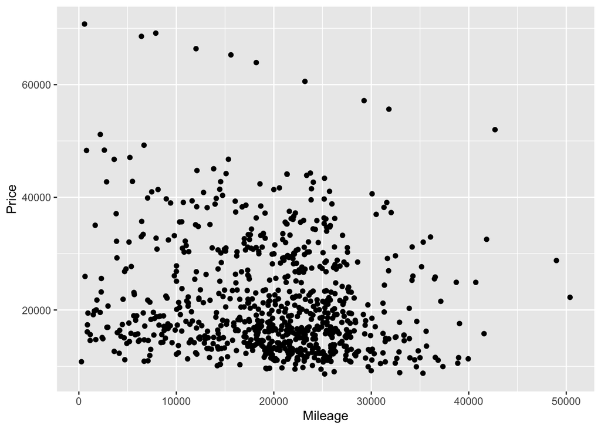

```r
ggplot(carPrice) + geom_point(aes(y=Price,x=Mileage))
```

So… interesting, but a bit hard to understand. We can probably do better.

At this point I probably need to point out that tibbles are nice and tidy, but sometimes we want to know the names of all our columns… (which is not easy to see using the print method for `tibble` that we made use of above - mainly because I am lazy and do not like scrolling through the list at the top of the displayed table that we outputted by typing `carPrice`). Luckily base R has a solution:

```r
names(carPrice)
```

```
##  [1] "Price"    "Mileage"  "Make"     "Model"    "Trim"     "Type"
##  [7] "Cylinder" "Liter"    "Doors"    "Cruise"   "Sound"    "Leather"
```

And what about *all* of the data types?

```r
glimpse(carPrice)
```

```
## Rows: 804
## Columns: 12
## $ Price    <dbl> 17314.10, 17542.04, 16218.85, 16336.91, 16339.17, 15709.05, 1…
## $ Mileage  <dbl> 8221, 9135, 13196, 16342, 19832, 22236, 22576, 22964, 24021, …
## $ Make     <chr> "Buick", "Buick", "Buick", "Buick", "Buick", "Buick", "Buick"…
## $ Model    <chr> "Century", "Century", "Century", "Century", "Century", "Centu…
## $ Trim     <chr> "Sedan 4D", "Sedan 4D", "Sedan 4D", "Sedan 4D", "Sedan 4D", "…
## $ Type     <chr> "Sedan", "Sedan", "Sedan", "Sedan", "Sedan", "Sedan", "Sedan"…
## $ Cylinder <dbl> 6, 6, 6, 6, 6, 6, 6, 6, 6, 6, 6, 6, 6, 6, 6, 6, 6, 6, 6, 6, 6…
## $ Liter    <dbl> 3.1, 3.1, 3.1, 3.1, 3.1, 3.1, 3.1, 3.1, 3.1, 3.1, 3.6, 3.6, 3…
## $ Doors    <dbl> 4, 4, 4, 4, 4, 4, 4, 4, 4, 4, 4, 4, 4, 4, 4, 4, 4, 4, 4, 4, 4…
## $ Cruise   <dbl> 1, 1, 1, 1, 1, 1, 1, 1, 1, 1, 1, 1, 1, 1, 1, 1, 1, 1, 1, 1, 1…
## $ Sound    <dbl> 1, 1, 1, 0, 0, 1, 1, 1, 0, 1, 0, 1, 1, 1, 1, 1, 0, 1, 1, 1, 1…
## $ Leather  <dbl> 1, 0, 0, 0, 1, 0, 0, 0, 1, 1, 0, 0, 0, 1, 1, 0, 0, 1, 0, 1, 0…
```

(Note: baseR has a similar function called `str` which does largely the same thing - why don’t you try it out? If you can’t work out how to use it, then try typing `?str` at your console window in RStudio - see this page for a quick intro if you have no idea yet about how that works: https://rladiessydney.org/courses/ryouwithme/01-basicbasics-1/)

Hmmm… a number of the variables look like they should really be categorical variables (often termed factors in R). For example, what is going on with `Make` and `Model`?

```r
carPrice$Make
```

```
##   [1] "Buick"     "Buick"     "Buick"     "Buick"     "Buick"     "Buick"
##   [7] "Buick"     "Buick"     "Buick"     "Buick"     "Buick"     "Buick"
##  [13] "Buick"     "Buick"     "Buick"     "Buick"     "Buick"     "Buick"
##  [19] "Buick"     "Buick"     "Buick"     "Buick"     "Buick"     "Buick"
##  [25] "Buick"     "Buick"     "Buick"     "Buick"     "Buick"     "Buick"
##  [31] "Buick"     "Buick"     "Buick"     "Buick"     "Buick"     "Buick"
##  [37] "Buick"     "Buick"     "Buick"     "Buick"     "Buick"     "Buick"
##  [43] "Buick"     "Buick"     "Buick"     "Buick"     "Buick"     "Buick"
##  [49] "Buick"     "Buick"     "Buick"     "Buick"     "Buick"     "Buick"
##  [55] "Buick"     "Buick"     "Buick"     "Buick"     "Buick"     "Buick"
##  [61] "Buick"     "Buick"     "Buick"     "Buick"     "Buick"     "Buick"
##  [67] "Buick"     "Buick"     "Buick"     "Buick"     "Buick"     "Buick"
##  [73] "Buick"     "Buick"     "Buick"     "Buick"     "Buick"     "Buick"
##  [79] "Buick"     "Buick"     "Cadillac"  "Cadillac"  "Cadillac"  "Cadillac"
##  [85] "Cadillac"  "Cadillac"  "Cadillac"  "Cadillac"  "Cadillac"  "Cadillac"
```

[output cut: 119 more lines]

Or using another way of getting it (from the tidyverse)

```r
carPrice %>% select(Model)
```

| Model |
| --- |
| Century |
| Century |
| Century |
| Century |
| Century |
| Century |
| Century |
| Century |
| Century |
| Century |

[output cut: 794 more lines]

What is the difference between these?

```r
str(carPrice$Make)
```

```
##  chr [1:804] "Buick" "Buick" "Buick" "Buick" "Buick" "Buick" "Buick" ...
```

```r
is.vector(carPrice$Make)
```

```
## [1] TRUE
```

```r
carPrice %>% select(Model) %>% str
```

```
## tibble [804 × 1] (S3: tbl_df/tbl/data.frame)
##  $ Model: chr [1:804] "Century" "Century" "Century" "Century" ...
```

So one returns a vector, the other returns a tibble. Different strokes for different folks… but this can sometimes be a very important thing to know about in R, as different datatypes can behave very differently with different functions and packages. Can we learn to do things one way only? Not really. In the end you will need to be familiar with both approaches, but for now you should try to do everything you can using the tidyverse as it is much more straightforward. However, you are likely to come across problems that you cannot resolve in the tidyverse, and for that you will need to return to base R, or even use some other package! (See this page about why it is worth teaching the tidyverse first: http://varianceexplained.org/r/teach-tidyverse/ - he convinced me - this is the philosophy we have adopted for this subject!)

Anyhoo… after that slight distraction, we were looking at categorical variables. One thing we might want to do is try out a boxplot on these kinds of variables. This gives a nice way to display the distribution of a continuous variable over a set of discrete variables. For example:

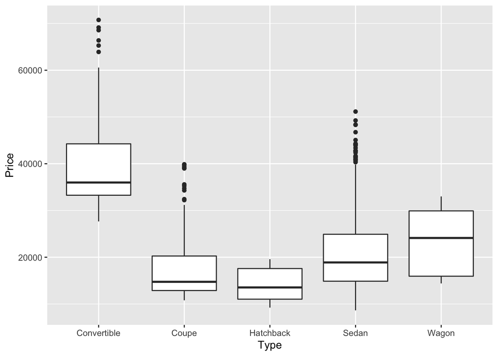

```r
ggplot(carPrice) + geom_boxplot(aes(y=Price,x=Type))
```

So, thinking about what this data means… quite a bit of variation of the Price as we vary the Type of car can be seen now. Does this seem right? Aren’t we leaving an important variable out?

**Question:** what else in our variable set would be very likely to change the price of a car?

While you are pondering that question, you should think about what the box plots are telling you. Try running `?geom_boxplot` and looking at what the help pages tell you. It is essential that you start learning how to read these! So try to work your way through it, even if you find it hard to follow! One strategy that might help could be to google boxplots (or just start with the wikipedia page which has quite a good explanation: https://en.wikipedia.org/wiki/Box_plot).

Make sure you can explain what these things are indicating to someone next to you:

1. The square bit
2. The line inside the square
3. The lines that hang off the square
4. The dots

Anyhoo… back to that question that I asked you above. One thing we would expect to affect sales `Price` would be the `Make` of the car! Some brands should be more expensive than others, and it is quite likely that some vary more than others…

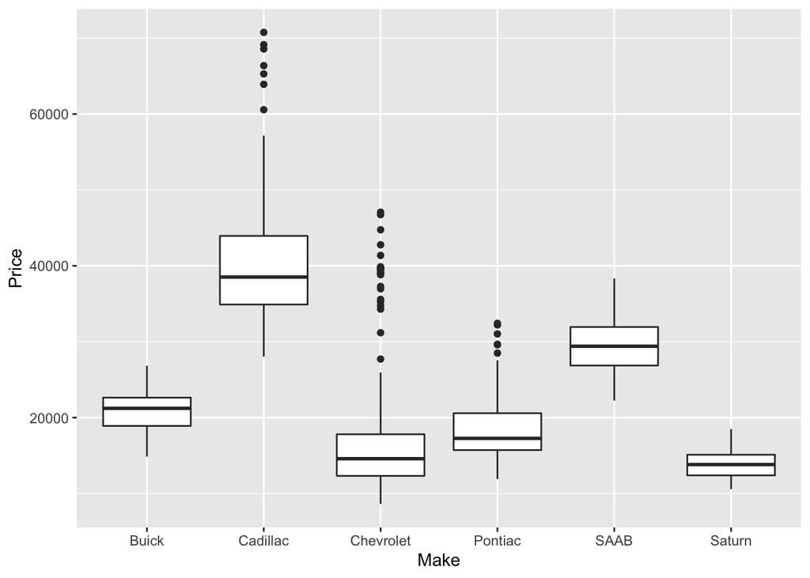

```r
ggplot(carPrice) + geom_boxplot(aes(y=Price,x=Make))
```

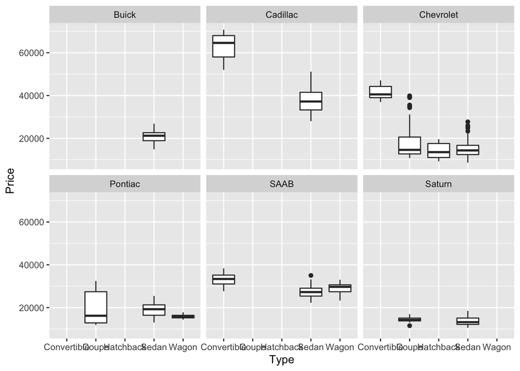

```r
ggplot(carPrice) + geom_boxplot(aes(y=Price, x=Type)) + facet_wrap(~Make)
```

Interesting indeed. Why don’t you try explaining what is going on to somebody sitting next to you. You might also want to try doing a similar exploratory trick with some other variables.

One final trick before we move onto getting some more data in a different way. We would expect that these effects might show up in our scatter plot too. How could we show this up?

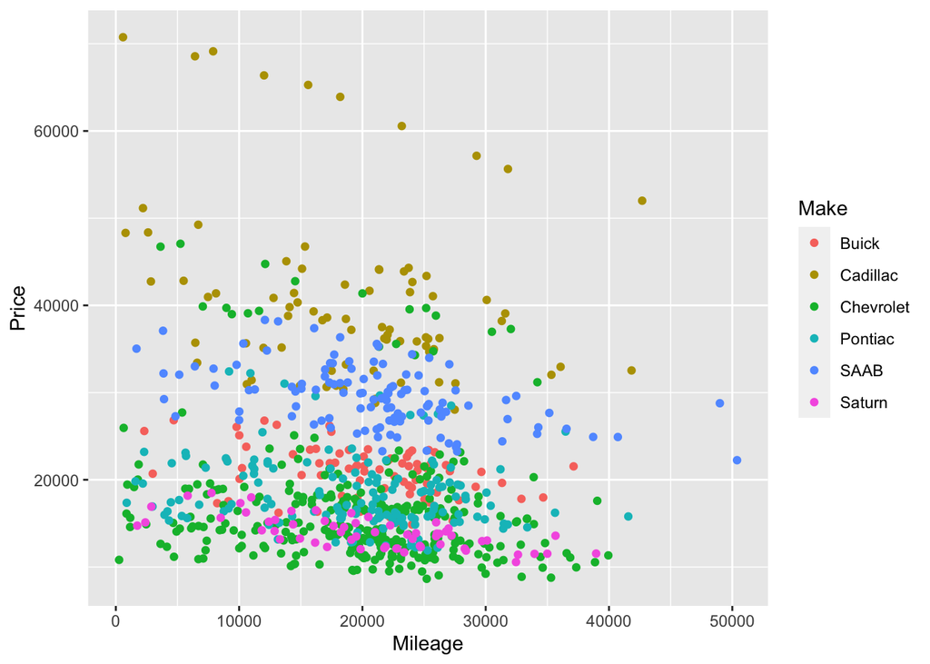

```r
ggplot(carPrice) + geom_point(aes(y=Price, x=Mileage, color=Make))
```

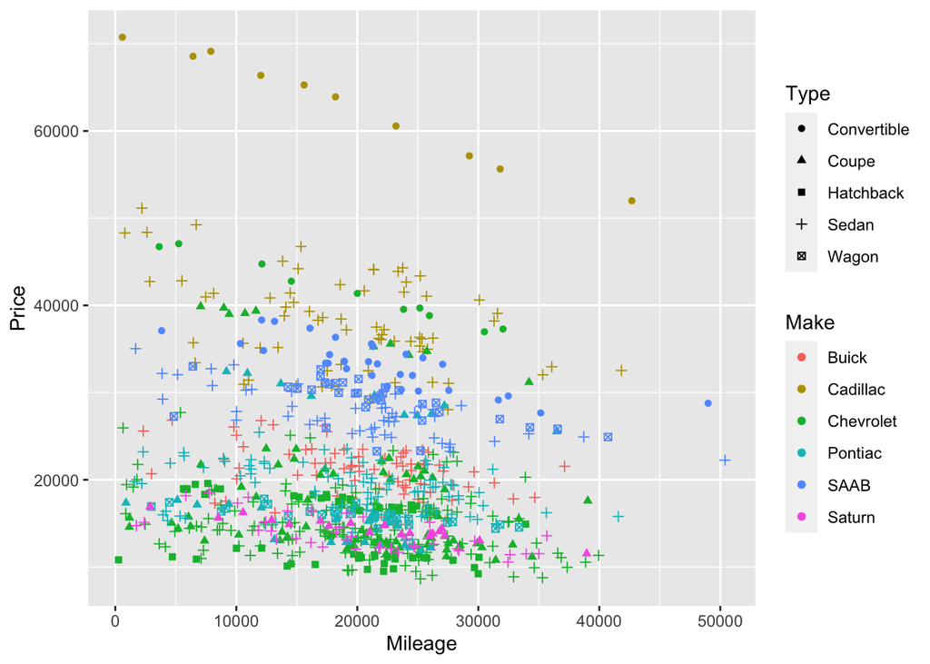

```r
ggplot(carPrice) + geom_point(aes(y=Price, x=Mileage, color=Make, shape=Type))
```

So there are lots of ways to start working out what is going on in this dataset… what else could you try? This is not a particularly readable plot, although it contains quite a bit of information.

### Challenge 1

Can you work out a nice way to convey the same information more clearly using ggplot? Go wild and show off your new R skills to your class mates :)

You might want to have a look at one of these pages for some ideas:

- https://www.data-to-viz.com/
- https://evamaerey.github.io/ggplot2_grammar_guide/about

# Option 2: Read directly from the web

You don’t actually have to download the file if you can rely on your data connection.

- Pro: if the data updates then you will get it automatically.
- Con: you are going to be downloading that data more than once which can be a bit wasteful (try investigating the `cache=TRUE` option in Rmd if you want to limit this). You can also find that the data disappears sometimes… or changes (Indeed - that happened to me in updating this workbook once! Took ages to get `rSDMX` working again… grumble grumble.)

The choice is yours really - and will probably depend on the situation. I tend to prefer direct fetch from the web as often my datasets get updated, but there are plenty of times when you will not have to do this. Anyway - you should really know *how* to do it, which goes like this:

```r
#reading in the data using a very easy to use command from the readr package:
physics_grades <- read_csv("https://raw.githubusercontent.com/bot13956/datasets/master/introduction_to_physics_grades.csv")
```

Note that there is a difference between `read_csv` (which is from the tidyverse and so returns a tibble) and `read.csv` (which is from base r and so returns a data.frame). Many pages and books will use `read.csv`. Go and try it! (You might have to access the help page with `?read.csv` to work out how). **My recommendation would be to use `read_csv` wherever you can**, as the resulting tibble will work much more nicely with tidyverse packages like `ggplot2` and `dplyr`.

## Getting to know your new data…

Ok… what is the structure of *this* dataset?

```r
glimpse(physics_grades)
```

```
## Rows: 799
## Columns: 3
## $ Count <dbl> 1, 2, 3, 4, 5, 6, 7, 8, 9, 10, 11, 12, 13, 14, 15, 16, 17, 18, 1…
## $ Score <dbl> 75.0, 5.0, 20.0, 87.5, 100.0, 97.5, 95.0, 30.0, 65.0, 37.5, 100.…
## $ Grade <chr> "C", "F", "F", "B", "A", "A", "A", "F", "D", "F", "A", "F", "C",…
```

What does our physics_grades data look like?

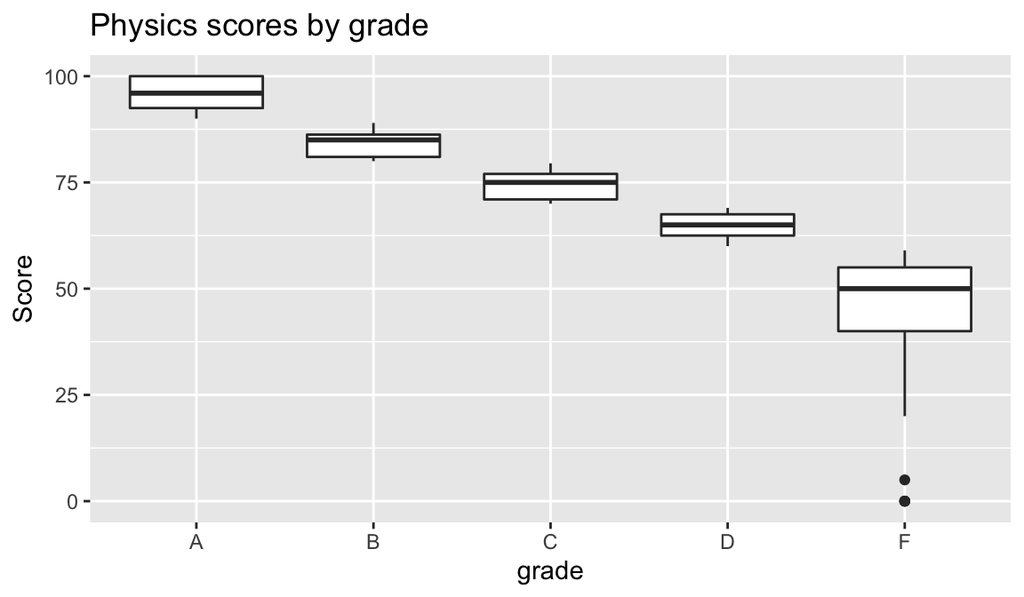

```r
ggplot(physics_grades, aes(x = factor(Grade), y = Score)) +
  geom_boxplot() +
  labs(title = "Physics scores by grade",
       x = "grade")
```

# Option 3: Use tools designed to interface with APIs

An **excellent** place to try getting data from is the various statistics websites that governmental bodies around the world have set up, or using various public APIs released by various social media sites. The most legitimate way to do this is usually via an API (or Application Programming Interface) that they have set up to facilitate this process. These normally run over HTTP, which stands for Hypertext Transfer Protocol. If you don’t know anything about that then you should probably go and have a look at one of these quickstart guides:

- https://zapier.com/learn/apis/chapter-2-protocols/ (more basic)
- https://code.tutsplus.com/tutorials/http-the-protocol-every-web-developer-must-know-part-1--net-31177 (a bit more technical)
- https://http.cat/ (an amusing site that *might* help you to understand HTTP status codes ;)

Fantastic! Lets go get some data!!!

**Warning:** this is often much more easily said than done. The more you practice using different tools to access different sites the better you will get at it. Luckily, you will get a lot of practice doing this during AT2! Make sure that you encourage everyone on you team to work on this data collection phase, as it is important that you build up your skills in this key area if you are going to be a successful data scientist!

## Part a: RSDMX - interfacing with XML based data repositiories

Here we will work through one method for using an API to interface with OECD data using the `rsdmx` package. It would be a very good idea for you to try out a couple of other methods to build up your familiarity with the types of things you might have to do (and how it can go wrong).

You will probably have to install this package using the `install.packages("rsdmx")` command, and load it. Try running `?rsdmx` and you will find out that the help for this package is pretty useless. However, there is a vignette associated with this package (how do I know that? Can you work out what function I use to see all the vignettes that I have on my computer?)

Let’s have a look at that vignette. If you run these commands in your terminal then the vignette should open in RStudio:

```r
library(rsdmx)
```

NB. You can check out the docs with this command `vignette("quickstart", package="rsdmx")`

You can find out about all of the SDMX service providers that rsdmx can access via this call

```r
providers <- getSDMXServiceProviders()
as.data.frame(providers)
```

| agencyId | name | scale | country | builder | compliant |
| --- | --- | --- | --- | --- | --- |
| ECB | European Central Bank | international | NA | SDMXREST21RequestBuilder | TRUE |
| ESTAT | Eurostat (Statistical office of the European Union) | international | NA | SDMXREST21RequestBuilder | TRUE |
| IMF | International Monetary Fund | international | NA | SDMXREST21RequestBuilder | TRUE |
| OECD | Organisation for Economic Cooperation and Development | international | NA | SDMXDotStatRequestBuilder | FALSE |
| UNICEF | United Nations International Children's Emergency Fund | international | NA | SDMXREST21RequestBuilder | TRUE |
| UNSD | United Nations Statistics Division | international | NA | SDMXREST21RequestBuilder | TRUE |
| FAO | Food and Agriculture Organization of the United Nations | international | NA | SDMXREST21RequestBuilder | FALSE |
| ILO_Legacy | International Labour Organization of the United Nations | international | NA | SDMXREST21RequestBuilder | FALSE |
| ILO | International Labour Organization of the United Nations | international | NA | SDMXREST21RequestBuilder | TRUE |
| UIS | UNESCO Institute of Statistics (old - http://data.uis.unesco.org) | international | NA | SDMXDotStatRequestBuilder | FALSE |

[output cut: 16 more lines]

Ooooo - lots of goodies in there. If you do the call without the forcing `as.data.frame` then you can even see the websites that get accessed (beware though - that is a fairly unreadable report so you have to pore over it in detail to understand what it is - you can try running `str(providers)` to find out more about the dataset… just be prepared for a lot of output!)

Right-o. The OECD makes its data available in SDMX via the interface provided at this page: https://data.oecd.org/ Go and have a look at the site. What can you find out? There are actually quite a few ways in which you can download OECD data from this site. Make sure you understand who the OECD are, and what types of interfaces they provide (not all are SDMX interfaces).

SDMX stands for Statistical Data and Metadata Exchange. It is a widely used standard for economic and population data providers. Queries to the provider via the API may be of two major types: data itself or description of data (metadata). So. We have decided we want to get some data from the OECD. Here is a very useful page that I found by doing a bit of browsing of the OECD data site: https://data.oecd.org/api/sdmx-ml-documentation/ (can you find it by following links from the top page?) Have a bit of a read of it, and try working out how you could interface with this API using the rsdmx package using that documentation.

So… here is an interesting screenshot from that page

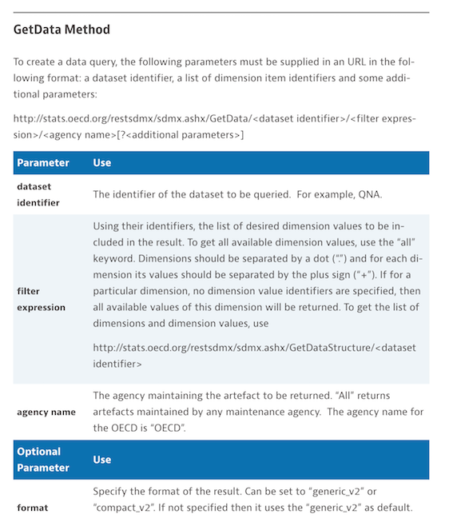

What does that mean about how we need to define the URL that we need in the call to `rsdmx`? (Which of you have read the help page for `readSDMX` alredy? Try looking that one up using the R help functionality.)

So. The first thing we need to do is find a database on the website that we are interested in. Try and find the link to the catalogue on the above webpage and have a look at what is available. So, for accessing OECD data, this page tells us that we minimally need:

- a dataset identifier
- a filter expression
- an agency name

The optional parameters listed below on that page (find them for an exercise) then tell you how you can filter the data to sub-intervals, or access other features in the database.

I am going to have a look at some data on employment rate vs educational attainment: http://www.oecd-ilibrary.org/education/data/education-at-a-glance/educational-attainment-and-labour-force-status_889e8641-en. Have a bit of a look at this page. What can you see that will help you use `rsdmx`? One thing to try out is *finding* this page of data from the root OECD data page (https://data.oecd.org/), which is well worth exploring anyway!

So first things first: I need to find the dataset identifier. It is “EAG_NEAC”. Can you see how I worked that out? (Hint: click on the “data” link.) The dataset will actually show you precisely what command to run if you want to download the data. I have decided just to download the data for Australia (as otherwise it gets very big!) You can filter the dataset for country and many other things. You should explore the relevant page until you can work out how I generated this link:

```r
(url<-"http://stats.oecd.org/restsdmx/sdmx.ashx/GetData/EAG_NEAC/AUS.L0T2+L0+L1_T_SC3T4+L2_T_SC2+L2_T_SC3T4+L3_T_SC2+L3T4+L3+L4+L5T8+L5+L6+L7+L8.T+F+M.Y25T64.T.VALUE+SE.NEAC_SHARE_EA/all?startTime=9999&endTime=9999")
```

```
## [1] "http://stats.oecd.org/restsdmx/sdmx.ashx/GetData/EAG_NEAC/AUS.L0T2+L0+L1_T_SC3T4+L2_T_SC2+L2_T_SC3T4+L3_T_SC2+L3T4+L3+L4+L5T8+L5+L6+L7+L8.T+F+M.Y25T64.T.VALUE+SE.NEAC_SHARE_EA/all?startTime=9999&endTime=9999"
```

Basically what I am doing is exploring the OECD site until I find a dataset of interest, filtering it to the bits of data I want, and then exporting the data using the SDMX option.

Let’s try a `rsdmx` command with that url:

```r
eag.neac <- readSDMX(url)
```

So what on earth did that just do? Try looking at the data - what format is it in? (Beware - you will get a **lot** of data if you just enter `eag.neac` in your R console, but try it out anyway! See what you get :) Your response is likely to be: Eeek!

Anyone at your table recognise this output format? It is XML. SDMX is an API built for this data standard. These days there are ones for JSON etc. too. You will need to explore and work out what format the API you are trying to deal with returns its data in and then interface with it as you can. Often this will require quite a bit of web searching, and then finessing of R packages that you find on the web.

(**Remember this:** Data science is often more of an art than a science. You are likely to spend most of your time trying to work out how to get data, and then get it into the format you need - the statistical analysis is often the easy part!)

Ok. We got our data. What can we do now? Well first we should probably make sure we got the data dictionary with the data frame (actually we did, but lets pretend we did not just for laughs as without the data dictionary you are not going to be able to work out what your variables are referring to!)

Lets try the call using the `rsdmx` helper function, which enables us to set an option to download this definition with our data (there are other ways to do this - see the help pages and the vignette.)

Remember the url we used? Lets translate that into the helper function format:

```r
url
```

```
## [1] "http://stats.oecd.org/restsdmx/sdmx.ashx/GetData/EAG_NEAC/AUS.L0T2+L0+L1_T_SC3T4+L2_T_SC2+L2_T_SC3T4+L3_T_SC2+L3T4+L3+L4+L5T8+L5+L6+L7+L8.T+F+M.Y25T64.T.VALUE+SE.NEAC_SHARE_EA/all?startTime=9999&endTime=9999"
```

```r
eag.neac_dsd <- readSDMX(#we are going to use the same parameters as we filtered on to get the direct url - make sure you can see how it all came out
  providerId ="OECD",
  resource ="data",
  flowRef ="EAG_NEAC",
  key ="/AUS.L0T2+L0+L1_T_SC3T4+L2_T_SC2+L2_T_SC3T4+L3_T_SC2+L3T4+L3+L4+L5T8+L5+L6+L7+L8.T+F+M.Y25T64.T.VALUE+SE.NEAC_SHARE_EA/all",
  key.mode ="SDMX",
  dsd =TRUE) #this is where we say we want the data definition
```

```
## [rsdmx][INFO] Fetching 'http://stats.oecd.org/restsdmx/sdmx.ashx/GetData/EAG_NEAC//AUS.L0T2+L0+L1_T_SC3T4+L2_T_SC2+L2_T_SC3T4+L3_T_SC2+L3T4+L3+L4+L5T8+L5+L6+L7+L8.T+F+M.Y25T64.T.VALUE+SE.NEAC_SHARE_EA/all/all'
## [rsdmx][INFO] DSD ref identified in dataset = 'EAG_NEAC'
## [rsdmx][INFO] Attempt to fetch & bind DSD to dataset
## [rsdmx][INFO] Fetching 'http://stats.oecd.org/restsdmx/sdmx.ashx/GetDataStructure/EAG_NEAC'
## [rsdmx][INFO] DSD fetched and associated to dataset!
```

Oooo - that message looks promising. What do we have now?

```r
(employment <- as.data.frame(eag.neac_dsd))
```

|  | COUNTRY | ISC11A | SEX | AGE | FIELD | MEASURE | INDICATOR | TIME_FORMAT | POWERCODE | obsTime | obsValue | OBS_STATUS |
| --- | --- | --- | --- | --- | --- | --- | --- | --- | --- | --- | --- | --- |
| 1 | AUS | L0T2 | T | Y25T64 | T | SE | NEAC_SHARE_EA | P1Y | 0 | 2015 | 0.24821110 | NA |
| 2 | AUS | L0T2 | T | Y25T64 | T | SE | NEAC_SHARE_EA | P1Y | 0 | 2016 | 0.24027565 | NA |
| 3 | AUS | L0T2 | T | Y25T64 | T | SE | NEAC_SHARE_EA | P1Y | 0 | 2017 | 0.23314694 | NA |
| 4 | AUS | L0T2 | T | Y25T64 | T | SE | NEAC_SHARE_EA | P1Y | 0 | 2018 | 0.22680216 | NA |
| 5 | AUS | L0T2 | T | Y25T64 | T | SE | NEAC_SHARE_EA | P1Y | 0 | 2019 | 0.23216030 | NA |
| 6 | AUS | L0T2 | T | Y25T64 | T | SE | NEAC_SHARE_EA | P1Y | 0 | 9999 | 0.23216030 | NA |
| 7 | AUS | L1_T_SC3T4 | F | Y25T64 | T | VALUE | NEAC_SHARE_EA | P1Y | 0 | 1989 | NA | xb |
| 8 | AUS | L1_T_SC3T4 | F | Y25T64 | T | VALUE | NEAC_SHARE_EA | P1Y | 0 | 1991 | NA | xb |
| 9 | AUS | L1_T_SC3T4 | F | Y25T64 | T | VALUE | NEAC_SHARE_EA | P1Y | 0 | 1993 | NA | xb |
| 10 | AUS | L1_T_SC3T4 | F | Y25T64 | T | VALUE | NEAC_SHARE_EA | P1Y | 0 | 1994 | NA | xb |

[output cut: 1424 more lines]

Cool. Now we have a thing that we have rather naturally turned into a `data.frame`, but it is not very easy to understand! We are going to have to work to make sense of this data by ourselves. (Make sure you keep looking back at the OECD pages to try and understand what we have here!)

The good thing about this second way of calling `readSDMX` is that it makes quite clear what we are doing with respect to the API documentation. The bad thing is that we have to work out how to do it ourselves, as the OECD page returns the link for us automatically. Different courses for different horses :)

Let’s start tidying up our data so that we can work out what is going on in there.

First. Let’s remove that AUS column. We *asked* for data just from Australia, so we don’t need it.

```r
library(magrittr)
employment %<>% select(-COUNTRY)
```

What is in the POWERCODE variable? Sort of looks like it might be all zeros? And what about TIME_FORMAT? If it is just information about some format then we probably don’t need that…

```r
employment %>% filter(POWERCODE!=0)
```

| ISC11A | SEX | AGE | FIELD | MEASURE | INDICATOR | TIME_FORMAT | POWERCODE | obsTime | obsValue | OBS_STATUS |
| --- | --- | --- | --- | --- | --- | --- | --- | --- | --- | --- |

```r
employment %>% filter(TIME_FORMAT!="P1Y")
```

| ISC11A | SEX | AGE | FIELD | MEASURE | INDICATOR | TIME_FORMAT | POWERCODE | obsTime | obsValue | OBS_STATUS |
| --- | --- | --- | --- | --- | --- | --- | --- | --- | --- | --- |

Yup. All zeros for POWERCODE, and all P1Y for TIME_FORMAT. Let’s drop them too

```r
employment %<>% select(-POWERCODE, -TIME_FORMAT)
```

The `ISC11A` column looks like a categorical variable to me. (How did I work that out?) Let’s try looking it using a boxplot:

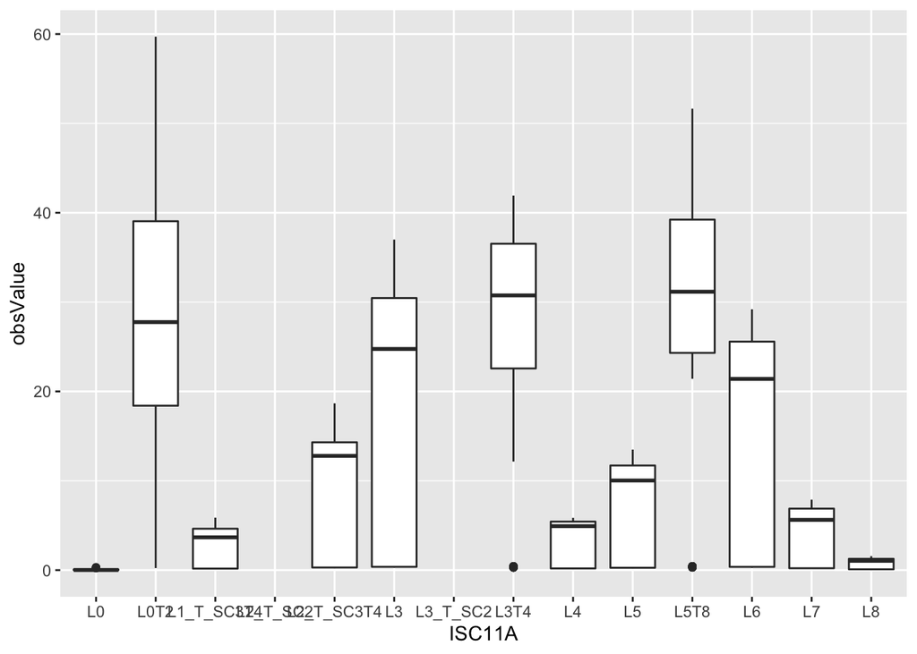

```r
employment %>% ggplot() + geom_boxplot(aes(x=ISC11A,y=obsValue))
```

And over time?

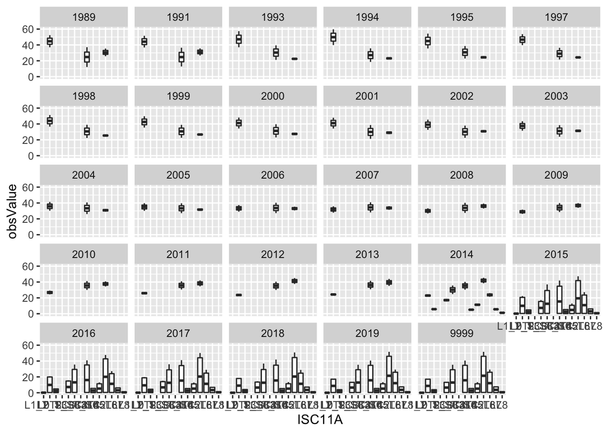

```r
employment %>% ggplot() + geom_boxplot(aes(x=ISC11A, y=obsValue))+facet_wrap(~obsTime)
```

Ha! Now we are getting somewhere… So we seem to have the `obsValue` as a percentage of something plotted against educational levels (how do I know that?) over a number of years…. What can you see in there? Can you explain what is going on? What else can you find out about this data?

### Challenge 3

Can you work out a good visualisation of this data? You might need to do some reshaping of your data (see this chapter in R4DS: http://r4ds.had.co.nz/tidy-data.html). You might want to think about making the educational levels understandable too… how could you do that? (Hint: you will probably have to find a table that lists them and then map that into the dataset you have…)

You can get more information about `rsdmx` in the quickstart guide (see instructions above). Make sure you are starting to get familiar with all this. You are quite likely to find tools like this very useful for Assessment 2! You might find this cheat sheet helpful: https://github.com/sdmx-twg/sdmx-rest/blob/master/v2_1/ws/rest/docs/rest_cheat_sheet.pdf

Note: the developer doc for the OECD site tells me that it provides data in JSON format too now. If you are used to dealing with this format, then you might want to explore this set of pages: https://data.oecd.org/api/sdmx-json-documentation/ (I have not used this format with the OECD before, so have no idea how easy this is to use… but it always helps to have multiple ways you can access data - not all sites will use your favourite format!)

## Part b: httr

Lying somewhere between a full data API service, and all out webscraping is the `httr` package (which is basically a wrapper for curl - ignore that comment if you don’t know what I am talking about!) It is not in the core tidyverse, but is designed to be compatible with it. If you don’t already have it then you will need to make sure you install it! (using `install.packages("httr")`).

How does it work? Try typing in `?httr` and do a bit of exploring of the help pages that come up… Note that there are demos for using this package with various OAuth protocols: four for 1.0 (linkedin, twitter, vimeo, and yahoo) and eight for 2.0 (azure, facebook, github, google, linkedin, reddit, yahoo, and yelp). That is a LOT of sites where you might be looking for data! A pretty useful looking package eh? So how does it work?

There are three very useful vignettes provided with the httr package:

- https://cran.r-project.org/web/packages/httr/vignettes/quickstart.html
- https://cran.r-project.org/web/packages/httr/vignettes/api-packages.html
- https://cran.r-project.org/web/packages/httr/vignettes/secrets.html

as well as the httr manual:

- https://cran.r-project.org/web/packages/httr/httr.pdf

Here I will reproduce the `github_api` function Hadley Wickham provides in the API packages vignette (above). It is a really nice example of best practice from the Master. **As an important note**, until you are really proficient using APIs I **strongly** recommend you stick with the `GET` verb, that way you are unlikely to get into trouble or make yourself very unpopular with the providers of the API! For simplicity and demonstration purposes, we are starting this example with an API that doesn’t require authentication.

The function provides the following tasks:

1. Sends a GET request to github to find out about Hadley’s repos
2. Indicates whether the request returns a json or xml format
3. If in a json format, parses the json into text
4. Manually returns the response into an S3 object (check out **Advanced R** https://adv-r.hadley.nz/s3.html if you want to learn more about S3 objects.)

Make sure you understand what each part of the code below is doing.

```r
library(httr)
library(jsonlite)
github_api <- function(path) {
  url <- modify_url("https://api.github.com", path = path)

  resp <- GET(url)
  if (http_type(resp) != "application/json") {
    stop("API did not return json", call. = FALSE)
  }

  parsed <- jsonlite::fromJSON(content(resp, "text"), simplifyVector = FALSE)

  structure(
    list(
      content = parsed,
      path = path,
      response = resp
    ),
    class = "github_api"
  )
}

print.github_api <- function(x, ...) {
  cat("<GitHub ", x$path, ">\n", sep = "")
  str(x$content)
  invisible(x)
}

github_api("/users/hadley")
```

```
## <GitHub /users/hadley>
## List of 32
##  $ login              : chr "hadley"
##  $ id                 : int 4196
##  $ node_id            : chr "MDQ6VXNlcjQxOTY="
##  $ avatar_url         : chr "https://avatars.githubusercontent.com/u/4196?v=4"
##  $ gravatar_id        : chr ""
##  $ url                : chr "https://api.github.com/users/hadley"
##  $ html_url           : chr "https://github.com/hadley"
##  $ followers_url      : chr "https://api.github.com/users/hadley/followers"
##  $ following_url      : chr "https://api.github.com/users/hadley/following{/other_user}"
##  $ gists_url          : chr "https://api.github.com/users/hadley/gists{/gist_id}"
##  $ starred_url        : chr "https://api.github.com/users/hadley/starred{/owner}{/repo}"
##  $ subscriptions_url  : chr "https://api.github.com/users/hadley/subscriptions"
##  $ organizations_url  : chr "https://api.github.com/users/hadley/orgs"
```

[output cut: 19 more lines]

Alternatively, in this instance, you can automatically parse the json file into a named list using the default parser:

```r
library(httr)
github_api2 <- function(path) {
  url <- modify_url("https://api.github.com", path = path)

  resp <- GET(url)
  if (http_type(resp) != "application/json") {
    stop("API did not return json", call. = FALSE)
  }

  str(content(resp, "parsed"))
}
github_api2("/users/hadley")
```

```
## List of 32
##  $ login              : chr "hadley"
##  $ id                 : int 4196
##  $ node_id            : chr "MDQ6VXNlcjQxOTY="
##  $ avatar_url         : chr "https://avatars.githubusercontent.com/u/4196?v=4"
##  $ gravatar_id        : chr ""
##  $ url                : chr "https://api.github.com/users/hadley"
##  $ html_url           : chr "https://github.com/hadley"
##  $ followers_url      : chr "https://api.github.com/users/hadley/followers"
##  $ following_url      : chr "https://api.github.com/users/hadley/following{/other_user}"
##  $ gists_url          : chr "https://api.github.com/users/hadley/gists{/gist_id}"
##  $ starred_url        : chr "https://api.github.com/users/hadley/starred{/owner}{/repo}"
##  $ subscriptions_url  : chr "https://api.github.com/users/hadley/subscriptions"
##  $ organizations_url  : chr "https://api.github.com/users/hadley/orgs"
##  $ repos_url          : chr "https://api.github.com/users/hadley/repos"
```

[output cut: 18 more lines]

So… we have an R object, can you work out how to process the output into a dataframe? This is often the most challenging aspect of using tools like `httr`. Lots and lots of munging and stuffing around to get the data into a useable form… (Mainly because almost every API seems to organise its data differently!)

## More information

There are some really great web pages on `httr` for a variety of different APIs. So I am not going to go into it more here. Here is a collection fo examples for a variety of different APIs (so chase up the data munging problem there).

- A very comprehensive set of lectures and materials on “digital data collection” in R that works from basic through to quite advanced methods! http://blog.rolffredheim.com/2015/03/digital-data-collection-course.html
- http://tophcito.blogspot.com.au/2015/11/accessing-apis-from-r-and-little-r.html is a very nice walk through on working with APIs using `httr` and associated packages to work through a database similar to many of those you are likely to find in the wild, many of which are not so well documented as we would like ;)
- A tutorial that walks you through webpage structure and webscraping using `httr`: https://stanford.edu/~wpmarble/webscraping_tutorial/webscraping_tutorial.pdf
- This one uses `httr` to collect data from GitHub! https://www.tylerclavelle.com/code/2017/randapis/ (might be useful for AT2C when you want to start making claims about your contribution to the community!)

## Other potentially useful R packages, and API interfaces

- https://cran.r-project.org/web/packages/RCurl/index.html
- http://data.gov.au/ uses the CKAN API http://docs.ckan.org/en/ckan-2.5.2/api/ (so you can access via the `ckanr` package)
- http://stat.data.abs.gov.au/ uses SDMX (so you can access via the `rsdmx` package)
- http://thinktostart.com/analyzing-facebook-with-r/

There are a lot more! You should start linking to them in the discussion forum on this topic to help out your fellow class mates.

# Option 4: Scrape some data

Finally… sometimes you will find data on the web that is not directly downloadable as a spreadsheet or providing sensible API endpoints.

(BTW: if there is an alternative to this method then it is most polite to use it, some people get rather cranky if you use the method we are about to discuss on a domain where they have provided interfacing capabilities via an API. It can also be **directly forbidden** and possibly **illegal** to webscrape according to terms and conditions of some sites… so beware!)

In this scenario, we can webscrape, which returns unstructured HTML data. There are some great tools in R for doing this. We are going to discuss `rvest` here, as it is designed to work with `magrittr`, so is part of the tidyverse! Here are some good pages on how to use it:

- https://blog.rstudio.com/2014/11/24/rvest-easy-web-scraping-with-r/
- https://www.analyticsvidhya.com/blog/2017/03/beginners-guide-on-web-scraping-in-r-using-rvest-with-hands-on-knowledge/

```r
library(rvest)
```

Ok. Let’s get started. You should probably start by reading the vignette on selector gadget. Run this command to do that: `vignette("selectorgadget",package="rvest")` (NB: make sure you have `rvest` installed first!) This vignette is very good, and will explain to you how I got the line of code below:

```r
html <- read_html("https://www.uts.edu.au/about/university/facts-figures-and-rankings")
UTS.data <- html_nodes(html, "table:nth-child(5), th")
```

So that set of commands goes and gets the data about UTS that is stored on the page in the link. Go and have a look at the page! Try using selector gadget until you get the text that I have listed in the quotes above. (Look at the vignette if you are having trouble.)

The trouble is… the table format makes this fairly hard to process. (You can try, but I gave up ;) So, for example, we can look at this item:

```r
UTS.data
```

```
## {xml_nodeset (27)}
##  [1] <table><tbody>\n<tr>\n<th>Course type</th>\n\t\t\t<th>2018</th>\n\t\t\t< ...
##  [2] <th>Course type</th>
##  [3] <th>2018</th>
##  [4] <th>2019</th>
##  [5] <th>2020</th>
##  [6] <th>Diversity Indicator</th>
##  [7] <th>2018</th>
##  [8] <th>2019</th>
##  [9] <th>2020</th>
## [10] <th>Enrolled Faculty</th>
## [11] <th>Higher<br>\n\t\t\tdegree<br>\n\t\t\tresearch</th>
## [12] <th>Post<br>\n\t\t\tgraduate<br>\n\t\t\tcourse<br>\n\t\t\twork</th>
## [13] <th>UNDER<br>\n\t\t\tgraduate,<br>\n\t\t\tENABLING<br>\n\t\t\tAND<br>\n\ ...
## [14] <th>Total</th>
## [15] <th>Enrolled Faculty</th>
## [16] <th>Higher<br>\n\t\t\tdegree<br>\n\t\t\tresearch</th>
## [17] <th>Post<br>\n\t\t\tgraduate<br>\n\t\t\tCourse<br>\n\t\t\twork</th>
## [18] <th>UNDER<br>\n\t\t\tgraduate,<br>\n\t\t\tENABLING<br>\n\t\t\tAND<br>\n\ ...
## [19] <th>Total</th>
## [20] <th>Course type</th>
## ...
```

We have all the info we need, but we are going to need to do some magic with regular expressions to get this into one big table. Probably more than you want to explore at this point in time! (Although feel free to try and do it later!)

Luckily, there is another set of functions in `rvest` that make this very easy indeed. Here we are asking for rvest to extract the data from the first table on the page.

```r
UTS.table <- html_node(html, "table")
```

What do you think we have in our data now? Let’s have a look:

```r
UTS.table
```

```
## {html_node}
## <table>
## [1] <tbody>\n<tr>\n<th>Course type</th>\n\t\t\t<th>2018</th>\n\t\t\t<th>2019< ...
```

```r
html_table(UTS.table)
```

| Course type | 2018 | 2019 | 2020 |
| --- | --- | --- | --- |
| Higher degree research | 2139 | 2198 | 2289 |
| Postgraduate coursework | 10,702 | 10,203 | 10223 |
| Undergraduate, enabling and non-award | 33,214 | 33,858 | 33,816 |
| Total | 46,055 | 46,259 | 46,328 |
| Equivalent full-time student load (EFTSL) | 35,490 | 36,034 | 35,760 |

Oooh yeah. That’s what we want.

You will need to just keep playing with this to build up some knowledge about how to do it. If you have a background in web dev then you might find this set of methods very nice indeed for getting data!

Can we plot our dataset? For that we need to get it in tidy form. We need to turn the `chr` strings into `integers`, which is going to require removing the commas, and then coercing to an `int`. Also, the data is currently in a wide format. We need to get it into a long format:

```r
tidyUTS <- html_table(UTS.table) %>%
  pivot_longer(cols = c(`2018`,`2019`,`2020`), names_to = "year", values_to = "enrolled") %>%
  mutate(enrolled = parse_number(enrolled), year = parse_integer(year))
tidyUTS
```

| Course type | year | enrolled |
| --- | --- | --- |
| Higher degree research | 2018 | 2139 |
| Higher degree research | 2019 | 2198 |
| Higher degree research | 2020 | 2289 |
| Postgraduate coursework | 2018 | 10702 |
| Postgraduate coursework | 2019 | 10203 |
| Postgraduate coursework | 2020 | 10223 |
| Undergraduate, enabling and non-award | 2018 | 33214 |
| Undergraduate, enabling and non-award | 2019 | 33858 |
| Undergraduate, enabling and non-award | 2020 | 33816 |
| Total | 2018 | 46055 |

[output cut: 5 more lines]

Can we plot it now? (removing the “Total” from `Course type` and formatting the x and y axis labels)

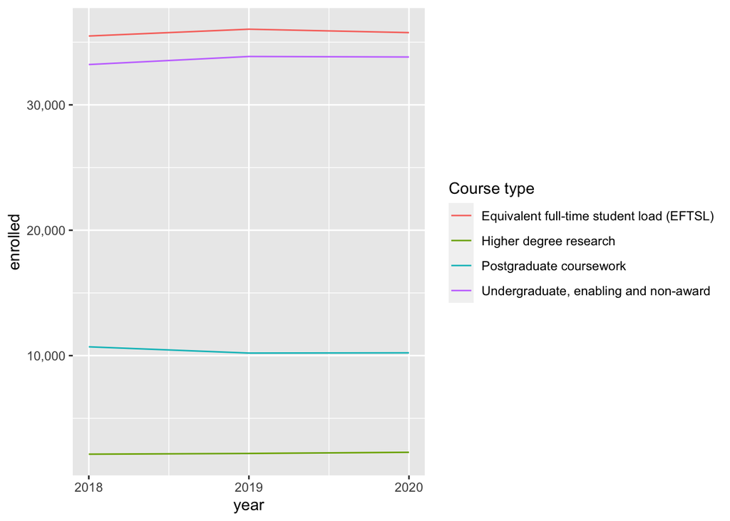

```r
tidyUTS %>%
  filter(`Course type` != "Total") %>%
  ggplot() +
  geom_line(aes(x =`year`, y =`enrolled`, color =`Course type`)) +
  scale_y_continuous(labels = scales::comma) +
  scale_x_continuous(n.breaks = 3)
```

Cool - that was actually rather easier than you might have expected after playing with `rsdmx` ;)

#### Summary

So web scraping might seem easier than using APIs, but it often involves a **lot** of wrangling, and is likely to annoy the people hosting a website if they have provided an API interface for you. Good to know how to do it, but be careful not to use it just because you can.

### More Resources

Here are some other places to start if you want to delve into this world:

- If you have a javascript page: https://www.datacamp.com/community/tutorials/scraping-javascript-generated-data-with-r
- Using a range of web based data collection techniques: http://www.columbia.edu/~cjd11/charles_dimaggio/DIRE/styled-4/styled-6/code-13/
- http://www.programmingr.com/examples/examples-web-scraping-r/